# Creating Fake Data Sets to Explore Hypothesis

Eurydice Aboagye

2023-03-22

### Question One

Think about an ongoing study in your lab (or a paper you have read in a different class), and decide on a pattern that you might expect in your experiment if a specific hypothesis were true.

*I am working on a Listeria biofilm study where i grew six Listeria isolates on stainless steel coupons and treated them with sanitizers at different concentrations. My null hypothesis is that there is no differnce in the effect of the sanitizers at different concentrations (0ppm, 50ppm, 100ppm and 200ppm)*

### Question Two

To start simply, assume that the data in each of your treatment groups follow a normal distribution. Specify the sample sizes, means, and variances for each group that would be reasonable if your hypothesis were true. You may need to consult some previous literature and/or an expert in the field to come up with these numbers.

```r
library(tidyverse)
```

```r
library(ggplot2)
library(ggthemes)
z <- read.table("BiofilmCounts.csv",header=TRUE,sep=",")
z <- z[complete.cases(z), ]
str(z$QAC_conc)
```

```r
summary(z)
```

```
##   Treatment         SanitizerType      SanitizerConc        reps
##  Length:100         Length:100         Min.   :  0.0   Min.   :1.00
##  Class :character   Class :character   1st Qu.:  0.0   1st Qu.:1.00
##  Mode  :character   Mode  :character   Median : 50.0   Median :1.00
##                                        Mean   : 78.5   Mean   :1.27
##                                        3rd Qu.:100.0   3rd Qu.:2.00
##                                        Max.   :200.0   Max.   :3.00
##      counts          counts.1         average           cfu
##  Min.   : 31.00   Min.   : 27.00   Min.   : 30.0   Min.   :8.600e+03
##  1st Qu.: 55.75   1st Qu.: 58.75   1st Qu.: 56.0   1st Qu.:3.252e+06
##  Median : 95.00   Median : 99.50   Median : 99.0   Median :1.308e+07
##  Mean   :109.79   Mean   :117.11   Mean   :113.5   Mean   :7.551e+07
##  3rd Qu.:141.00   3rd Qu.:146.25   3rd Qu.:140.5   3rd Qu.:1.035e+08
##  Max.   :630.00   Max.   :620.00   Max.   :625.0   Max.   :1.615e+09
##      logcfu
##  Min.   :3.934
##  1st Qu.:6.510
##  Median :7.116
##  Mean   :7.011
##  3rd Qu.:8.015
##  Max.   :9.208
```

```r
z1<-select(z, Treatment, SanitizerType, SanitizerConc, logcfu)


z1 %>%
  group_by(SanitizerConc)%>%
  summarise(AverageCfu=mean(logcfu), variance=var(logcfu), n=n()) ->z2
print(z2)
```

```
## # A tibble: 4 × 4
##   SanitizerConc AverageCfu variance     n
##           <int>      <dbl>    <dbl> <int>
## 1             0       7.47    0.716    33
## 2            50       6.86    1.50     23
## 3           100       6.91    1.31     21
## 4           200       6.59    1.92     23
```

### Question Three

Using the methods we have covered in class, write code to create a random data set that has these attributes. Organize these data into a data frame with the appropriate structure.

```r
isolates<-rep(c("A","B","C","D","E"),each=10)
control<-rnorm(50, mean = 7.47, sd=0.716)
low<-rnorm(50, mean=6.86, sd=1.50)
medium<-rnorm(50, mean=6.91, sd=1.31)
high<- rnorm(50, mean=6.59, sd=1.92)

dframe<- data.frame(isolates, control, low, medium, high)

head(dframe)
```

```
##   isolates  control      low   medium     high
## 1        A 8.076181 6.827894 8.023069 2.607845
## 2        A 7.480212 7.772806 5.070147 6.799228
## 3        A 8.480022 6.849193 7.459004 4.096361
## 4        A 7.052437 6.969094 4.124111 5.984065
## 5        A 5.780656 4.149007 8.098224 8.336765
## 6        A 7.366423 7.374216 6.669923 6.598632
```

```r
dframe %>%
  pivot_longer(cols= control:high, names_to = "SanitizerConc", values_to = "logcfu", values_drop_na=T) -> dframe2

head(dframe2)
```

```
## # A tibble: 6 × 3
##   isolates SanitizerConc logcfu
##   <chr>    <chr>          <dbl>
## 1 A        control         8.08
## 2 A        low             6.83
## 3 A        medium          8.02
## 4 A        high            2.61
## 5 A        control         7.48
## 6 A        low             7.77
```

### Question Four

Now write code to analyze the data (probably as an ANOVA or regression analysis, but possibly as a logistic regression or contingency table analysis. Write code to generate a useful graph of the data.

```r
one.way <- aov(logcfu ~ SanitizerConc, data=dframe2) #one way anova with logcfu as the outcome variable
summary(one.way) # null hypothesis is false.
```

```
##                Df Sum Sq Mean Sq F value   Pr(>F)
## SanitizerConc   3   66.6   22.20   11.27 7.47e-07 ***
## Residuals     196  386.1    1.97
## ---
## Signif. codes:  0 '***' 0.001 '**' 0.01 '*' 0.05 '.' 0.1 ' ' 1
```

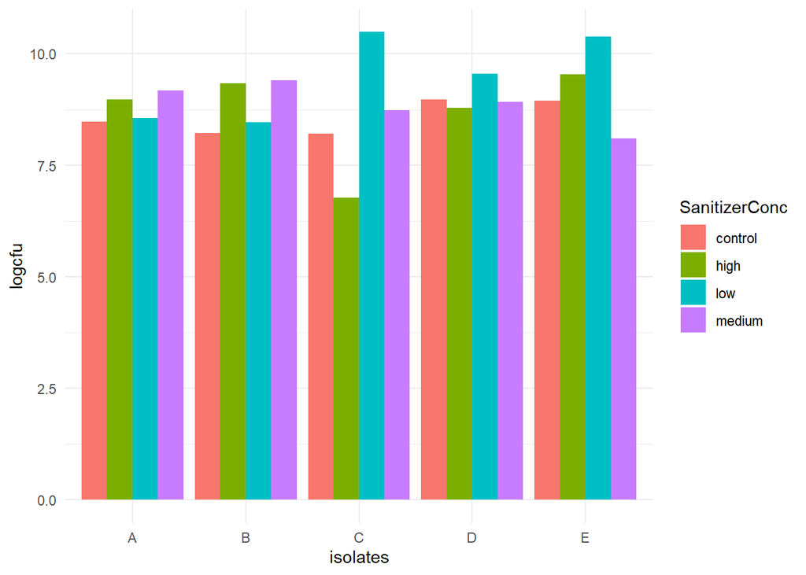

```r
plot1<-ggplot(dframe2) +
  geom_bar(aes(x = isolates, y = logcfu, fill = SanitizerConc ), stat = "identity", position = "dodge") +
  theme_minimal()
print(plot1)
```

```r
#I ran a posthoc analyses to determine significance within groups

TukeyHSD(one.way)
```

```
##   Tukey multiple comparisons of means
##     95% family-wise confidence level
##
## Fit: aov(formula = logcfu ~ SanitizerConc, data = dframe2)
##
## $SanitizerConc
##                      diff         lwr        upr     p adj
## high-control   -1.5318567 -2.25922295 -0.8044904 0.0000009
## low-control    -0.3272613 -1.05462758  0.4001049 0.6490870
## medium-control -0.8209395 -1.54830570 -0.0935732 0.0199915
## low-high        1.2045954  0.47722912  1.9319616 0.0001628
## medium-high     0.7109172 -0.01644901  1.4382835 0.0580699
## medium-low     -0.4936781 -1.22104437  0.2336881 0.2965062
```

### Question Five

Try running your analysis multiple times to get a feeling for how variable the results are with the same parameters, but different sets of random numbers.

```r
isolates<-rep(c("A","B","C","D","E"),each=10)
control<-rnorm(50, mean = 7.47, sd=0.716)
low<-rnorm(50, mean=6.86, sd=1.50)
medium<-rnorm(50, mean=6.91, sd=1.31)
high<- rnorm(50, mean=6.59, sd=1.92)

dframe1<- data.frame(isolates, control, low, medium, high)

head(dframe1)
```

```
##   isolates  control      low   medium     high
## 1        A 8.149312 5.943208 6.684693 7.107225
## 2        A 8.341305 5.470055 6.120067 9.941702
## 3        A 7.840298 3.614713 8.001739 6.081065
## 4        A 6.178761 7.577722 7.333624 8.590352
## 5        A 7.751305 9.500520 7.836513 4.948977
## 6        A 7.553851 9.437901 6.628098 6.794623
```

```r
dframe1 %>%
  pivot_longer(cols= control:high, names_to = "SanitizerConc", values_to = "logcfu", values_drop_na=T) -> dframe2

head(dframe2)
```

```
## # A tibble: 6 × 3
##   isolates SanitizerConc logcfu
##   <chr>    <chr>          <dbl>
## 1 A        control         8.15
## 2 A        low             5.94
## 3 A        medium          6.68
## 4 A        high            7.11
## 5 A        control         8.34
## 6 A        low             5.47
```

```r
one.way <- aov(logcfu ~ SanitizerConc, data=dframe2)
summary(one.way)#This time i reject the null hypothesis because p_value was significant
```

```
##                Df Sum Sq Mean Sq F value   Pr(>F)
## SanitizerConc   3   41.6  13.880    5.75 0.000864 ***
## Residuals     196  473.1   2.414
## ---
## Signif. codes:  0 '***' 0.001 '**' 0.01 '*' 0.05 '.' 0.1 ' ' 1
```

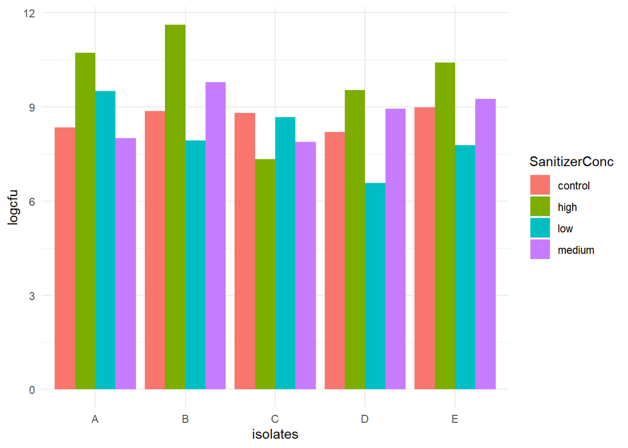

```r
plot2<-ggplot(dframe2) +
  geom_bar(aes(x = isolates, y = logcfu, fill = SanitizerConc ), stat = "identity", position = "dodge") +
  theme_minimal()
print(plot2)
```

```r
#I ran a posthoc analyses to determine significance within groups

TukeyHSD(one.way)
```

```
##   Tukey multiple comparisons of means
##     95% family-wise confidence level
##
## Fit: aov(formula = logcfu ~ SanitizerConc, data = dframe2)
##
## $SanitizerConc
##                      diff        lwr         upr     p adj
## high-control   -0.8303646 -1.6355198 -0.02520939 0.0404107
## low-control    -1.2596845 -2.0648397 -0.45452932 0.0004194
## medium-control -0.5672155 -1.3723707  0.23793974 0.2644958
## low-high       -0.4293199 -1.2344751  0.37583527 0.5123414
## medium-high     0.2631491 -0.5420061  1.06830434 0.8319269
## medium-low      0.6924691 -0.1126861  1.49762427 0.1191524
```

```r
isolates<-rep(c("A","B","C","D","E"),each=10)
control<-rnorm(50, mean = 7.47, sd=0.716)
low<-rnorm(50, mean=6.86, sd=1.50)
medium<-rnorm(50, mean=6.91, sd=1.31)
high<- rnorm(50, mean=6.59, sd=1.92)

dframe3<- data.frame(isolates, control, low, medium, high)

head(dframe3)
```

```
##   isolates  control      low   medium     high
## 1        A 8.257284 6.427988 6.334441 6.038032
## 2        A 7.249549 6.577399 8.466373 7.631002
## 3        A 6.117461 9.515988 7.660096 7.334067
## 4        A 6.682001 9.934783 6.307276 5.873612
## 5        A 6.714735 7.139296 5.341879 4.481006
## 6        A 8.406442 5.425235 5.515124 3.308082
```

```r
dframe %>%
  pivot_longer(cols= control:high, names_to = "SanitizerConc", values_to = "logcfu", values_drop_na=T) -> dframe4

head(dframe4)
```

```
## # A tibble: 6 × 3
##   isolates SanitizerConc logcfu
##   <chr>    <chr>          <dbl>
## 1 A        control         8.08
## 2 A        low             6.83
## 3 A        medium          8.02
## 4 A        high            2.61
## 5 A        control         7.48
## 6 A        low             7.77
```

```r
one.way <- aov(logcfu ~ SanitizerConc, data=dframe4)
summary(one.way)
```

```
##                Df Sum Sq Mean Sq F value   Pr(>F)
## SanitizerConc   3   66.6   22.20   11.27 7.47e-07 ***
## Residuals     196  386.1    1.97
## ---
## Signif. codes:  0 '***' 0.001 '**' 0.01 '*' 0.05 '.' 0.1 ' ' 1
```

```r
#I ran a posthoc analyses to determine significance within groups

TukeyHSD(one.way)
```

```
##   Tukey multiple comparisons of means
##     95% family-wise confidence level
##
## Fit: aov(formula = logcfu ~ SanitizerConc, data = dframe4)
##
## $SanitizerConc
##                      diff         lwr        upr     p adj
## high-control   -1.5318567 -2.25922295 -0.8044904 0.0000009
## low-control    -0.3272613 -1.05462758  0.4001049 0.6490870
## medium-control -0.8209395 -1.54830570 -0.0935732 0.0199915
## low-high        1.2045954  0.47722912  1.9319616 0.0001628
## medium-high     0.7109172 -0.01644901  1.4382835 0.0580699
## medium-low     -0.4936781 -1.22104437  0.2336881 0.2965062
```

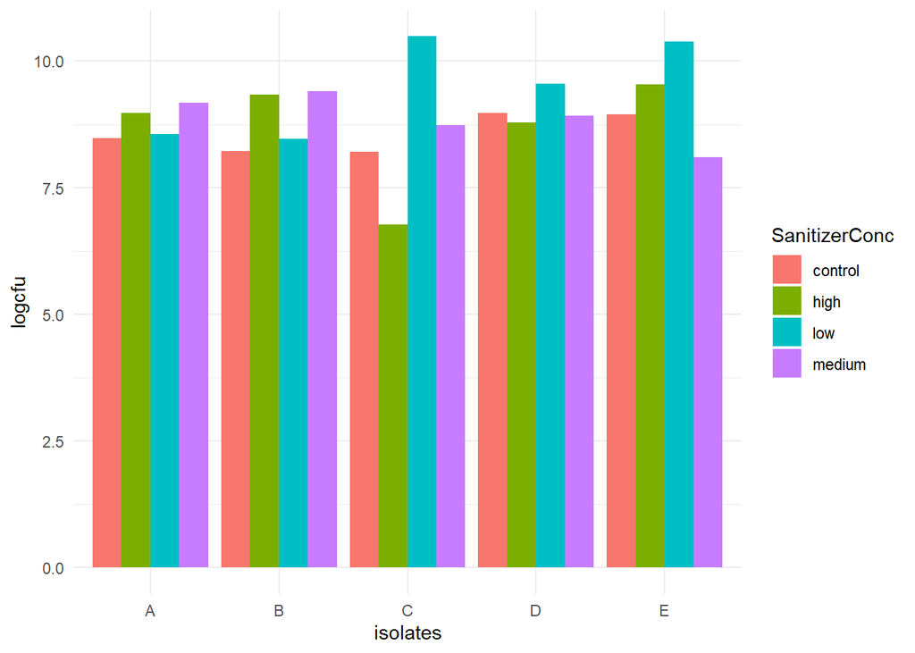

```r
plot3<-ggplot(dframe4) +
  geom_bar(aes(x = isolates, y = logcfu, fill = SanitizerConc ), stat = "identity", position = "dodge") +
  theme_minimal()
print(plot3)
```

### Question Six

Now begin adjusting the means of the different groups. Given the sample sizes you have chosen, how small can the differences between the groups be (the “effect size”) for you to still detect a significant pattern (p < 0.05)?

```r
#now varying the means to determine effect sizes

isolates<-rep(c("A","B","C","D","E"),each=10)
control<-rnorm(50, mean = 6.47, sd=0.716) #adjusted the means to be closer to treatment values
low<-rnorm(50, mean=6.86, sd=1.50)
medium<-rnorm(50, mean=6.91, sd=1.31)
high<- rnorm(50, mean=6.99, sd=1.92)# Adjusted the mean to be closer to the medium values

dframe<- data.frame(isolates, control, low, medium, high)

head(dframe)
```

```
##   isolates  control      low   medium     high
## 1        A 5.996357 7.695942 7.555650 3.701789
## 2        A 7.843048 7.287481 6.070577 2.711033
## 3        A 6.107521 5.461622 7.912375 7.408030
## 4        A 7.663691 8.965655 6.979692 6.547251
## 5        A 5.406475 5.999262 8.089439 5.142248
## 6        A 5.890282 7.614981 7.247685 6.349614
```

```r
dframe %>%
  pivot_longer(cols= control:high, names_to = "SanitizerConc", values_to = "logcfu", values_drop_na=T) -> dframe2

head(dframe2)
```

```
## # A tibble: 6 × 3
##   isolates SanitizerConc logcfu
##   <chr>    <chr>          <dbl>
## 1 A        control         6.00
## 2 A        low             7.70
## 3 A        medium          7.56
## 4 A        high            3.70
## 5 A        control         7.84
## 6 A        low             7.29
```

```r
one.way <- aov(logcfu ~ SanitizerConc, data=dframe2)
summary(one.way) #Null hypothesis was true with the adjusted means...
```

```
##                Df Sum Sq Mean Sq F value Pr(>F)
## SanitizerConc   3   11.7   3.908   1.967   0.12
## Residuals     196  389.4   1.987
```

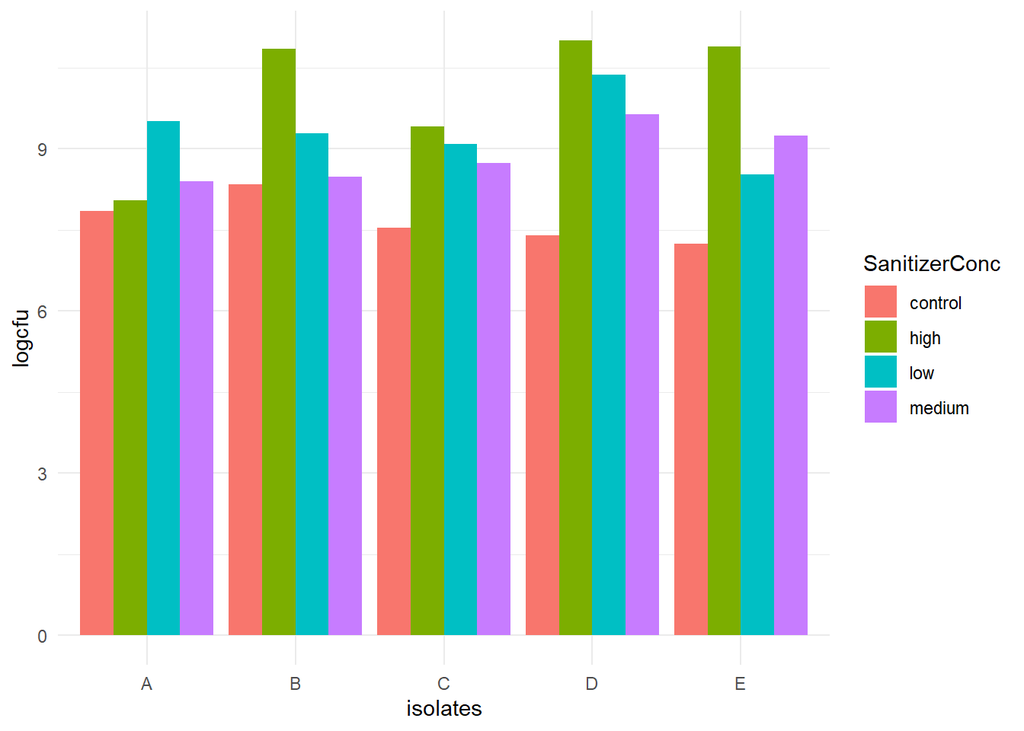

```r
plot1<-ggplot(dframe2) +
  geom_bar(aes(x = isolates, y = logcfu, fill = SanitizerConc ), stat = "identity", position = "dodge") +
  theme_minimal()
print(plot1)
```

```r
#I ran a posthoc analyses to determine significance within groups

TukeyHSD(one.way)
```

```
##   Tukey multiple comparisons of means
##     95% family-wise confidence level
##
## Fit: aov(formula = logcfu ~ SanitizerConc, data = dframe2)
##
## $SanitizerConc
##                      diff        lwr       upr     p adj
## high-control    0.5715913 -0.1588986 1.3020812 0.1814117
## low-control     0.6099795 -0.1205104 1.3404694 0.1371169
## medium-control  0.4313427 -0.2991472 1.1618326 0.4215217
## low-high        0.0383882 -0.6921017 0.7688781 0.9990960
## medium-high    -0.1402486 -0.8707385 0.5902413 0.9595580
## medium-low     -0.1786368 -0.9091267 0.5518531 0.9210608
```

```r
#running the model a few times with the same parameters set to get a feeling for the effect of random variation in the data.

isolates<-rep(c("A","B","C","D","E"),each=10)
control<-rnorm(50, mean = 6.47, sd=0.716) #adjusted the means to be closer to treatment values
low<-rnorm(50, mean=6.86, sd=1.50)
medium<-rnorm(50, mean=6.91, sd=1.31)
high<- rnorm(50, mean=6.99, sd=1.92)# Adjusted the mean to be closer to the medium values

dframe<- data.frame(isolates, control, low, medium, high)

head(dframe)
```

```
##   isolates  control      low   medium      high
## 1        A 7.350391 8.731540 6.559897  7.413397
## 2        A 6.370262 3.855618 7.340921  4.000281
## 3        A 5.705043 6.050815 6.273807  6.040166
## 4        A 5.916293 7.392542 7.083344  7.547693
## 5        A 7.257605 7.053032 7.265521 10.627247
## 6        A 5.828443 8.065436 4.762735  5.965464
```

```r
dframe %>%
  pivot_longer(cols= control:high, names_to = "SanitizerConc", values_to = "logcfu", values_drop_na=T) -> dframe2

head(dframe2)
```

```
## # A tibble: 6 × 3
##   isolates SanitizerConc logcfu
##   <chr>    <chr>          <dbl>
## 1 A        control         7.35
## 2 A        low             8.73
## 3 A        medium          6.56
## 4 A        high            7.41
## 5 A        control         6.37
## 6 A        low             3.86
```

```r
one.way <- aov(logcfu ~ SanitizerConc, data=dframe2)
summary(one.way)
```

```
##                Df Sum Sq Mean Sq F value Pr(>F)
## SanitizerConc   3    6.9   2.295   1.131  0.338
## Residuals     196  397.8   2.030
```

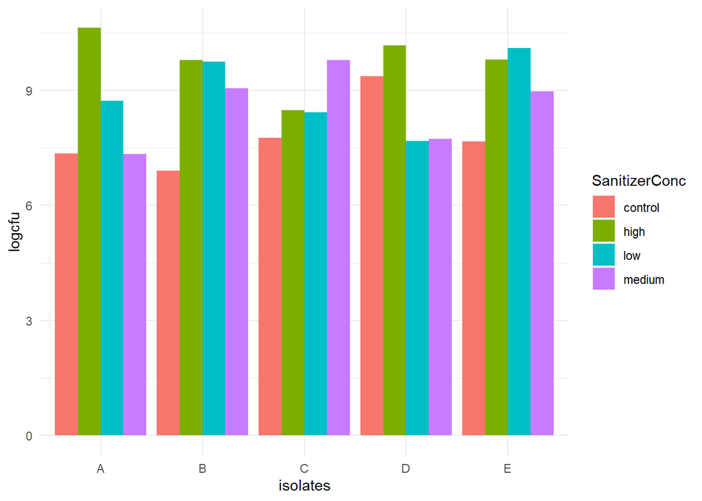

```r
plot1<-ggplot(dframe2) +
  geom_bar(aes(x = isolates, y = logcfu, fill = SanitizerConc ), stat = "identity", position = "dodge") +
  theme_minimal()
print(plot1)
```

```r
TukeyHSD(one.way)
```

```
##   Tukey multiple comparisons of means
##     95% family-wise confidence level
##
## Fit: aov(formula = logcfu ~ SanitizerConc, data = dframe2)
##
## $SanitizerConc
##                      diff        lwr       upr     p adj
## high-control    0.5038098 -0.2345288 1.2421483 0.2918548
## low-control     0.1270457 -0.6112929 0.8653843 0.9703523
## medium-control  0.2327112 -0.5056274 0.9710498 0.8465291
## low-high       -0.3767640 -1.1151026 0.3615745 0.5498812
## medium-high    -0.2710986 -1.0094372 0.4672400 0.7770435
## medium-low      0.1056655 -0.6326731 0.8440040 0.9825459
```

*one last run*

```r
isolates<-rep(c("A","B","C","D","E"),each=10)
control<-rnorm(50, mean = 6.47, sd=0.716) #adjusted the means to be closer to treatment values
low<-rnorm(50, mean=6.86, sd=1.50)
medium<-rnorm(50, mean=6.91, sd=1.31)
high<- rnorm(50, mean=6.99, sd=1.92)# Adjusted the mean to be closer to the medium values

dframe<- data.frame(isolates, control, low, medium, high)

head(dframe)
```

```
##   isolates  control      low   medium      high
## 1        A 6.836344 6.849217 7.008036  2.583749
## 2        A 7.080242 6.568733 6.689916  4.328881
## 3        A 5.884966 5.778129 8.639446  5.237692
## 4        A 5.417979 6.689884 4.676323 11.367383
## 5        A 7.994257 8.715543 7.784056  5.149081
## 6        A 6.919280 8.485138 7.555179  5.647073
```

```r
dframe %>%
  pivot_longer(cols= control:high, names_to = "SanitizerConc", values_to = "logcfu", values_drop_na=T) -> dframe2

head(dframe2)
```

```
## # A tibble: 6 × 3
##   isolates SanitizerConc logcfu
##   <chr>    <chr>          <dbl>
## 1 A        control         6.84
## 2 A        low             6.85
## 3 A        medium          7.01
## 4 A        high            2.58
## 5 A        control         7.08
## 6 A        low             6.57
```

```r
one.way <- aov(logcfu ~ SanitizerConc, data=dframe2)
summary(one.way)
```

```
##                Df Sum Sq Mean Sq F value Pr(>F)
## SanitizerConc   3   13.2   4.400   1.965  0.121
## Residuals     196  438.9   2.239
```

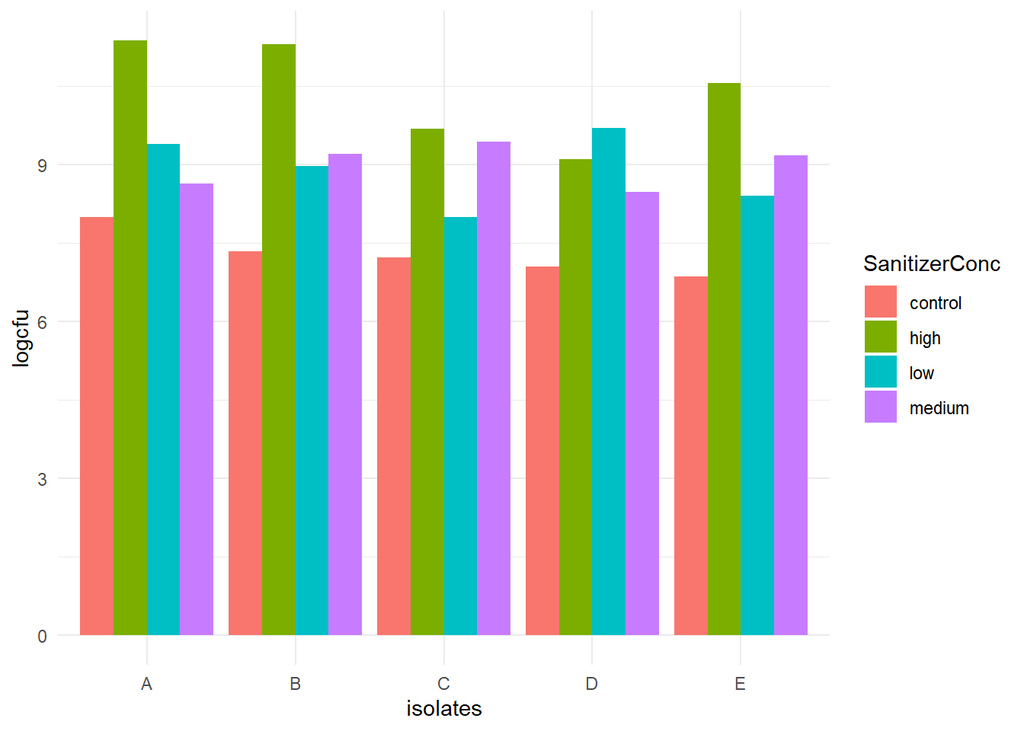

```r
plot1<-ggplot(dframe2) +
  geom_bar(aes(x = isolates, y = logcfu, fill = SanitizerConc ), stat = "identity", position = "dodge") +
  theme_minimal()
print(plot1)
```

```r
TukeyHSD(one.way)
```

```
##   Tukey multiple comparisons of means
##     95% family-wise confidence level
##
## Fit: aov(formula = logcfu ~ SanitizerConc, data = dframe2)
##
## $SanitizerConc
##                       diff        lwr       upr     p adj
## high-control    0.66998320 -0.1055405 1.4455069 0.1165465
## low-control     0.43045925 -0.3450645 1.2059830 0.4770801
## medium-control  0.57818422 -0.1973395 1.3537079 0.2181357
## low-high       -0.23952394 -1.0150477 0.5359998 0.8542057
## medium-high    -0.09179897 -0.8673227 0.6837247 0.9899607
## medium-low      0.14772497 -0.6277987 0.9232487 0.9604466
```